# Government is what you make of it

## What does this have to do with anything?

## What does this have to do with anything?

- First in a series of readings that discuss civic data
- Provides context for the paradigm that you'll be operating in for group projects
- Use your HUM critical reading skills

## Government is what you make of it

## Context

- What is this piece?
- Who is the author?
- Who is his audience?

## Argument

- How do you characterize his main thesis?
- How does he support this thesis?

## My take

- We are in a new era where the capacity of a government to serve the citizens can be increased through open data and civic engagement with that data. Advice to make that interaction successful:
  - Open doors
  - Create a sense of community
  - back good people with real support
  - Make it count

## Lingering questions?

- What does the author expect to be the **value** of civic data?

## ggplot2

What is the relationship between the carat of diamonds and their price, when you're comparing diamonds of the same cut quality?

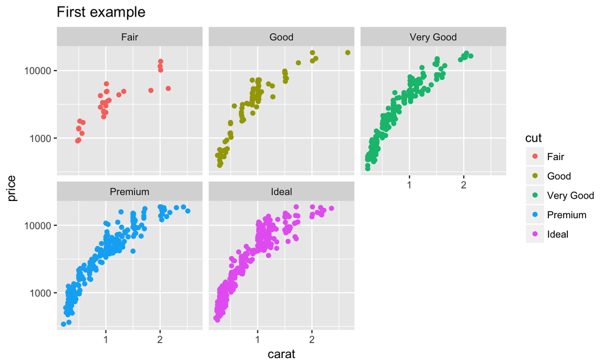

## A look at the code

```r
library(tidyverse)
ggplot(small, aes(x = carat, y = price)) +
  geom_point(aes(colour = cut)) +
  scale_y_log10() +
  facet_wrap(~cut) +
  ggtitle("First example")
```

## Variations on syntax

```r
ggplot(small) +
  geom_point(aes(x = carat, y = price, colour = cut))
```

versus

```r
ggplot(small, aes(c = carat, y = price, colour = cut)) +
  geom_point()
```

## A subtlety to be aware of

There is a difference between **setting** and **mapping** aesthetics.

1. Mapping dynamically links data to aesthetics through `aes()`.
2. Setting a parameter to a fixed value is done *outside* of `aes`.

Don't mix!

## ggplot2 vs base

**Strengths** - Make beautiful graphics very fast. - Enforces best practices. - Easy to update/modify plots. - Make highly customized plots very efficiently.

**Weaknesses** - No 3d plotting or dynamic plots (see `ggvis`). - Can be difficult for unorthodox plots. - Slower processing time.

## Where to find these functions

First decide a geometry that is appropriate for the data type and the relationship you're aiming to show.

```
http://docs.ggplot2.org/
```

Once you settled on a geometry, you need to map data to aesthetics. You can also look for help.

## Activity 2

**Carbon**: Take a look at the first few rows of the `CO2` dataset that is built-in to R.

1. Make a scatterplot of concentration versus uptake for this dataset.
2. Add color to indicate which plant is associated with each datapoint.
3. Connect the points with lines.
4. Add size to indicate the type.

**Oregon Voter History**: For this exercise you'll be working with a random sample of the full oregon voter history file. They can be downloaded using the following code:

```r
library(tidyverse)
vote_particip <- read_csv("http://bit.ly/2l1bIxs")
```

Use this data to craft a visualization that sheds light on a question that you have about htis data. In addition to your visualization, please include some commentary that touches on issues such as:

- your motivating question
- what type of variables you're using (e.g. categorical vs. numeric)
- wht you decided to map those variables to particular visual cues through aesthetics
- why you used the geometry that you did
- what additional tweaks you made (if any) to improve the clarity of the graphic (you may want to refer to Tufte's principles)
- what does this graphic tell you about your motivating question?